# Análise e Previsão de Vendas - Walmart

Gustavo Almeida Silva

# O trabalho proposto e o conjunto de dados

Nesse trabalho, temos o objetivo de prever a quantidade de vendas de produtos em lojas da rede Walmart, onde buscaremos analisar a correlação de datas importantes, como feriados, Super Bowls e finais de ano com essa quantidade de produtos vendidos

Para esse estudo, temos o seguinte conjunto de dados

```r
(walmart_data=readr::read_csv("Walmart.csv")%>%
                        mutate(Date=dmy(Date)))
```

```
## # A tibble: 6,435 × 8
##    Store Date       Weekly_Sales Holiday_Flag Temperature Fuel_P…¹   CPI Unemp…²
##    <dbl> <date>            <dbl>        <dbl>       <dbl>    <dbl> <dbl>   <dbl>
##  1     1 2010-02-05     1643691.            0        42.3     2.57  211.    8.11
##  2     1 2010-02-12     1641957.            1        38.5     2.55  211.    8.11
##  3     1 2010-02-19     1611968.            0        39.9     2.51  211.    8.11
##  4     1 2010-02-26     1409728.            0        46.6     2.56  211.    8.11
##  5     1 2010-03-05     1554807.            0        46.5     2.62  211.    8.11
##  6     1 2010-03-12     1439542.            0        57.8     2.67  211.    8.11
##  7     1 2010-03-19     1472516.            0        54.6     2.72  211.    8.11
##  8     1 2010-03-26     1404430.            0        51.4     2.73  211.    8.11
##  9     1 2010-04-02     1594968.            0        62.3     2.72  211.    7.81
## 10     1 2010-04-09     1545419.            0        65.9     2.77  211.    7.81
## # … with 6,425 more rows, and abbreviated variable names ¹Fuel_Price,
## #   ²Unemployment
```

E os seguintes eventos foram considerados para a analise da correlação

- Super Bowl (é o jogo final do campeonato da NFL (National Football League)
- Labor Day (dia do trabalho)
- Thanksgiving (ação de graças, e na sexta é a black friday)
- Christmas (natal)

# Entendendo e observando os dados

Antes de qualquer tipo de tomada de decisão com os dados, é importantíssimo uma análise exploratória, buscando entender e observar as relações que esses podem possuir

Para isso, utilizaremos como nossa variável principal para a análise, a quantidade de produtos vendidos por semana. Obtendo uma amostra aleatória de 10 lojas diferentes, temos o seguinte gráfico

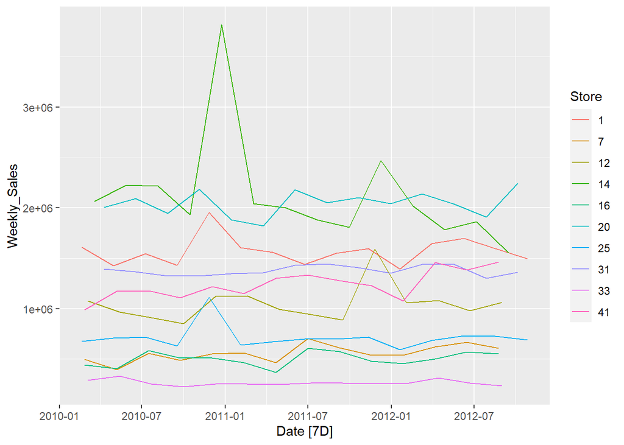

```r
ts_walmart_data=walmart_data %>%
                  as_tsibble(key=Store,index=Date)



ts_walmart_data%>%
  filter(Store==sample(length(unique(ts_walmart_data$Store)),10))%>%
  autoplot(.vars=Weekly_Sales )
```

Observando o gráfico, é possivel notar 2 pontos importantes.

- Série Temporal
  - Os dados utilizados nesse estudo se tratam de observações medidas ao longo do tempo, se tratando portanto de uma série temporal
  - Devemos buscar observar as seguintes propriedades nos dados: **Tendencia, Ciclos e Sazonalidade**
- Variabilidade entre as lojas
  - Apesar de ser possivel observar certa sazonalidade dos dados, o ponto marcante está na diferença entre a quantidade de produtos em cada loja. Certas lojas possuem uma quantidade de produtos vendidos mais estacionaria que outras lojas, onde portanto a busca por modelos individuais pode ser processado demorado de humana e computacional
  - Para contornar esse problema, utilizaremos a estatística de média, onde o resulatdo final do conjunto de dados será apenas a média de cada coluna por dia

Aplicando a transformação nos dados:

```r
ts_walmart_data=walmart_data %>%
                  as_tsibble(key=Store,index=Date)

ts_walmart_meaned_data=walmart_data%>%
                            group_by(Date)%>%
                            summarise_all(mean)%>%
                            select(-Store)%>%
                            as_tsibble(index=Date)%>%
                            mutate(Date=yearweek(Date))
```

Para facilitar a manipulação de dados de Série temporal, utilizaremos o objeto *tsibble* do pacote **Fable**, que foi desenvolvido para dados e modelos dessa natureza

Assim, temos o seguinte gráfico das vendas médias pelo tempo

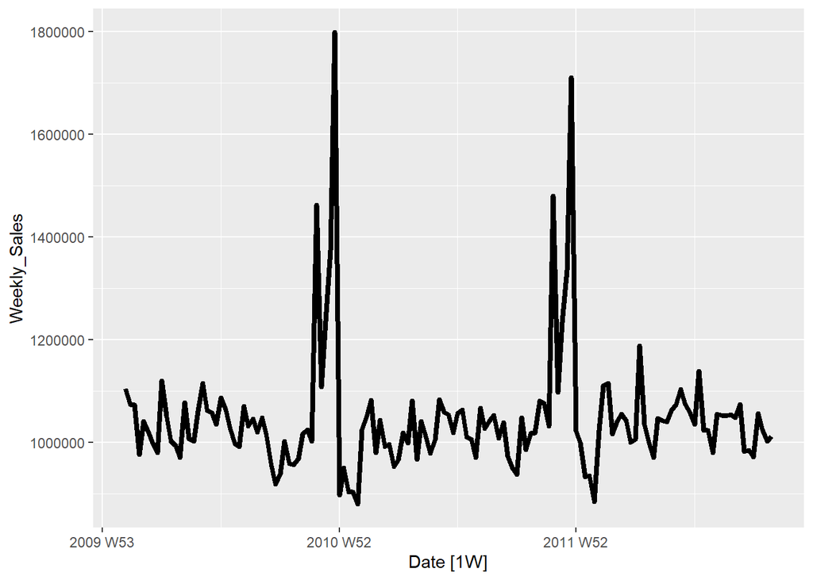

```r
ts_walmart_meaned_data%>%
  autoplot(.vars=Weekly_Sales,lwd=1.5)
```

# Propondo o modelo

Tendo os dados organizados e ja feito a análise exploratoria, chegamos na parte de propor um modelo.

- **Tendência**
  - Uma tendência existe quando há um aumento ou diminuição de longo prazo nos dados. Não precisa ser linear. Às vezes, nos referiremos a uma tendência como “mudança de direção”, quando ela pode passar de uma tendência crescente para uma tendência decrescente
- **Sazonalidade**
  - Um padrão sazonal ocorre quando uma série temporal é afetada por fatores sazonais, como a época do ano ou o dia da semana.A sazonalidade é sempre de um período fixo e conhecido.
- **Ciclos**
  - Um ciclo ocorre quando os dados exibem aumentos e quedas que não são de uma frequência fixa.

## Teste de Tendência

Observando o gráfico de vendas de produtos pelo tempo, tem-se a impressão da Série temporal ser estacionária, e portano iremos testar essa hipótese.

Para isso, iremos utilizar o **Teste de Dickey-Fuller Aumentado** com $5\%$ de significancia, onde temos as seguintes hipóteses

$$H_0:\text{Tendencia não estacionaria ; }
H_1:\text{Tendencia estacionaria}$$

```r
  tseries::adf.test(ts_walmart_meaned_data$Weekly_Sales)
```

```
##
##  Augmented Dickey-Fuller Test
##
## data:  ts_walmart_meaned_data$Weekly_Sales
## Dickey-Fuller = -5.3039, Lag order = 5, p-value = 0.01
## alternative hypothesis: stationary
```

Assim, temos um p-valor abaixo da significancia e rejeitamos a hipótese nula, ou seja, rejeitamos a hipotese da Série ser não estacionária com $5\%$ de significancia.

## Busca por Ciclos e Sazonalidade

Para observarmos Ciclos e Sazonalidade, utilizaremos os valores de $ACF$ e $PACF$, que são valores que indicam a correlação parcial e total entre cada lag

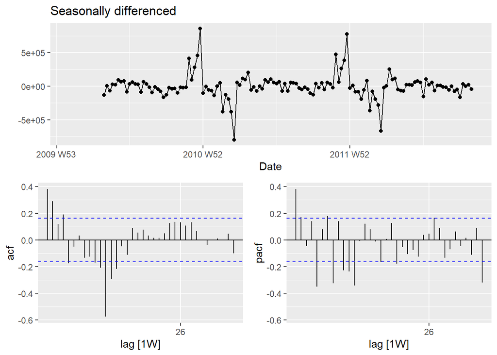

```r
ts_walmart_meaned_data %>%
  gg_tsdisplay(difference(Weekly_Sales, 12),
               plot_type='partial', lag=36) +
  labs(title="Seasonally differenced", y="")
```

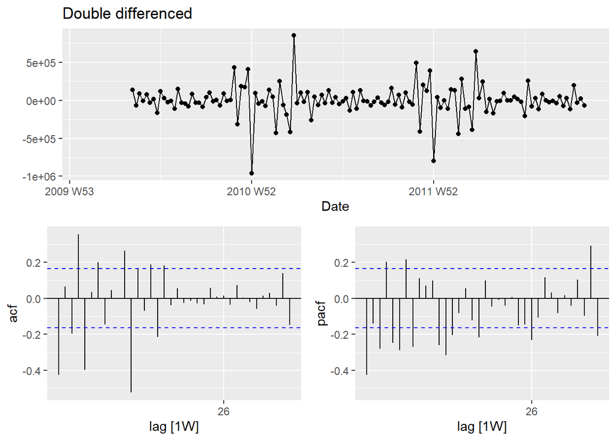

```r
ts_walmart_meaned_data %>%
  gg_tsdisplay(difference(Weekly_Sales, 12) %>% difference(),
               plot_type='partial', lag=36) +
  labs(title = "Double differenced", y="")
```

Utilizando os gráficos de $ACF$ e $PACF$ vemos uma alta correlação em um intervalo de lags $1$ e $12$ ou seja, a semana atual tem uma alta correlação com a semana passada, e a semana atual tem uma correlação moderada com 12 semanas para tras, que é em média o intervalo entre uma data importante e outra, ou seja, as datas importantes possuem uma correlação moderada. Tais correlações indicam que um modelo que utilize um plano sazonal em sua construção pode ser o mais adequado

## ARIMA Sazonal

Atraves do testes utilizados, foi visto que a Série não possui uma tendencia marcante, e possui forte sazonalidade.

Assim, o modelo proposto para essa série é o Auto Regressivo Integrado de Médias Móveis Sazonais, conhecido como **S-ARIMA**

Para isso, iremos iniciar o modelagem utilizando o **Auto-ARIMA**, um modelo onde a própria função do pacote utilizado irá analisar o comportamento da Série e propor as constantes do modelo

```r
auto_arima_walmart_fit=ts_walmart_meaned_data %>%
  model(arima = ARIMA(Weekly_Sales))


report(auto_arima_walmart_fit)
```

```
## Series: Weekly_Sales
## Model: ARIMA(1,1,1)(0,1,0)[52]
##
## Coefficients:
##          ar1      ma1
##       0.1275  -0.9089
## s.e.  0.1140   0.0418
##
## sigma^2 estimated as 1.696e+09:  log likelihood=-1083.75
## AIC=2173.5   AICc=2173.78   BIC=2181
```

O modelo proposto foi:
$$ARIMA(1,1,1)(0,1,0)$$
, que possui a seguinte previsäo para o intervalo de 1 ano

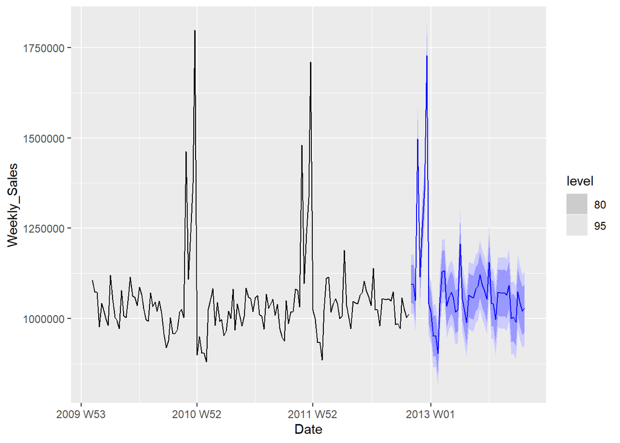

```r
forecast(auto_arima_walmart_fit, h='12 month') %>%
  autoplot(ts_walmart_meaned_data)
```

Com base no modelo base sugerido pelo pacote, iremos testar outras constantes e analisar o comportamento desses outros modelos. Para isso, iremos seguir a seguinte formula:

$$ARIMA\ (p,d,q)\ (P,D,Q)$$
Onde iremos variar os valores parte não sazonal do modelo $(p,d,q)$ e iremos fixar a parte sazonal do modelo $(P,D,Q)$ em (0,1,0)

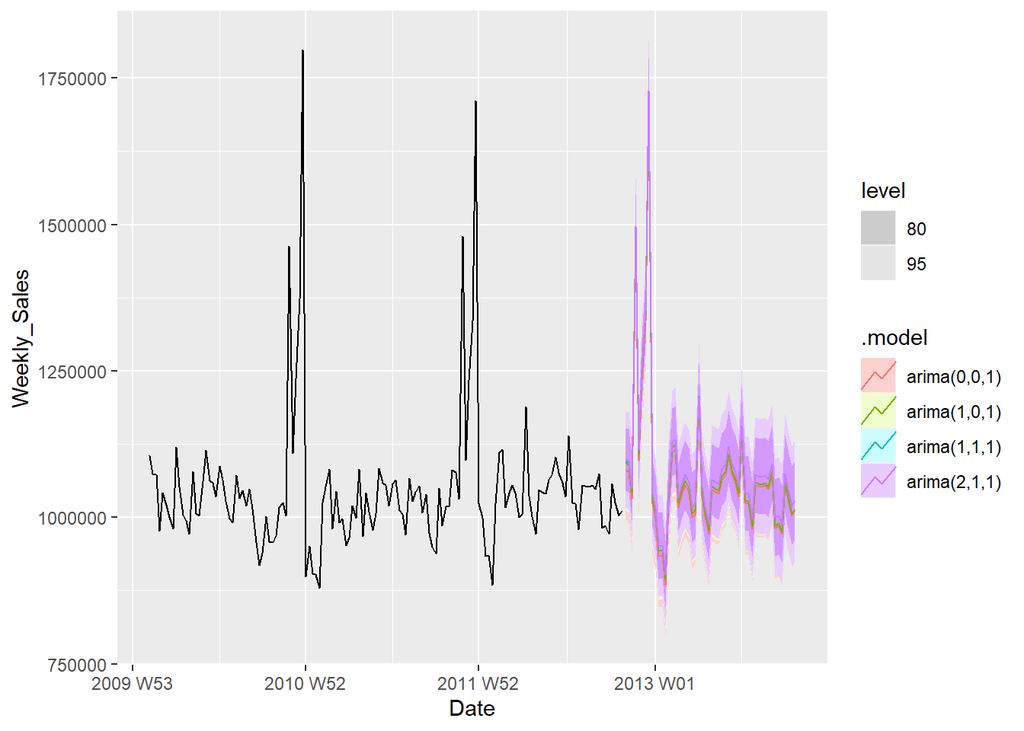

```r
others_arima_walmart_fit=ts_walmart_meaned_data %>%
  model("arima(0,0,1)"=ARIMA(Weekly_Sales ~ 0 + pdq(0,0,1)),
        "arima(1,0,1)"= ARIMA(Weekly_Sales ~ 0 + pdq(1,0,1)),
        "arima(1,1,1)"=ARIMA(Weekly_Sales ~ 0 + pdq(1,1,1)),
        "arima(2,1,1)"=ARIMA(Weekly_Sales ~ 0 + pdq(2,1,1)))


forecast(others_arima_walmart_fit, h='12 month') %>%
  autoplot(ts_walmart_meaned_data)
```

Para proseguirmos com o melhor modelo encontrado, estaremos interessados nos valores de scores: $AIC, AICc, BIC$

```r
report(others_arima_walmart_fit)%>%
  select(.model,AIC,AICc,BIC)%>%
  rename(Model=.model)%>%
  kbl(caption = "Scores dos Modelos") %>%
  kable_classic(full_width = F, html_font = "Cambria")
```

Scores dos Modelos

| Model | AIC | AICc | BIC |
| --- | --- | --- | --- |
| arima(0,0,1) | 2201.926 | 2202.063 | 2206.948 |
| arima(1,0,1) | 2196.555 | 2196.831 | 2204.087 |
| arima(1,1,1) | 2173.497 | 2173.776 | 2180.996 |
| arima(2,1,1) | 2174.792 | 2175.262 | 2184.791 |

Assim, vimos o modelo $ARIMA (1,1,1)$ foi o melhor encontrado, modelo esse que havia sido retornado pela função **Auto-ARIMA**, enquanto o modelo $ARIMA(2,1,1)$ apresentou resultados semelhantes, e portanto iremos proseguir com esses dois modelos para a análise de desempenho e acurácia

## Desempenho e acurácia

O conjunto de dados utilizado para construção e treinamento do modelo, tem o intervalo de tempo de começo de 2010 até o final de 2012. Assim, para avaliarmos a acurácia do modelo, iremos particionar os dados em 2 grupos, o grupo de teste e o grupo de treinamento

```r
traning_walmart_meaned_data=ts_walmart_meaned_data %>%
  stretch_tsibble(.init = 3, .step = 1)

df_accuraracy_values=traning_walmart_meaned_data %>%
  model(ARIMA(Weekly_Sales),
        ARIMA(Weekly_Sales ~0 + pdq(2,1,1))) %>%
  forecast(h = 1) %>%
  accuracy(ts_walmart_meaned_data)
```

```r
df_accuraracy_values%>%
  kbl(caption = "Acurácia dos Modelos") %>%
  kable_classic(full_width = F, html_font = "Cambria")
```

Acurácia dos Modelos

[output not shown]

Portando, vemos que os modelos apresentaram comportamentos parecidos, porem o $ARIMA(1,1,1)$ foi aquele que apresentou um $RMSE$ (Raiz Quadrada do Média do Erros) menor e portanto iremos utilizar ele para a previsão da quantidade de vendas de produtos em datas importante

# Análise das datas importantes

Iremos analisar as datas que näo estäo presentes no conjnto de dados utilizado, ou seja, datas mais recentes que o dia 26 de Outubro de 2012:

```r
holidays=data.frame(super_bowl=c(dmy("12-02-2010"),dmy("11-02-2011"),dmy("10-02-2012"),dmy("08-02-2013")),
                    labor_day=c(dmy("10-09-2010"),dmy("09-09-2011"),dmy("07-10-2012"),dmy("06-09-2013")),
                    thanksgiving=c(dmy("26-11-2010"),dmy("25-11-2011"),dmy("23-11-2012"),dmy("29-11-2013")),
                    christmas=c(dmy("31-12-2010"),dmy("30-12-2011"),dmy("28-12-2012"),dmy("27-12-2013"))) %>%
            as_tibble()
```

```r
auto_arima_1year_walmart=forecast(auto_arima_walmart_fit, h='15 month')

super_bowl_forecast=auto_arima_1year_walmart%>%
                      filter(Date==yearweek(holidays$super_bowl)[4])

labor_day_forecast=auto_arima_1year_walmart%>%
                      filter(Date==yearweek(holidays$labor_day)[4])

thank_forecast=auto_arima_1year_walmart%>%
                      filter(Date==yearweek(holidays$thanksgiving)[3] | Date==yearweek(holidays$thanksgiving)[4])

christmas_forecast=auto_arima_1year_walmart%>%
                      filter(Date==yearweek(holidays$christmas)[3] | Date==yearweek(holidays$christmas)[4])
```

Utilizando a estimativa pontual retornada pelo modelo, temos a seguinte comparação com os anos anteriores

- Super Bowl

```r
df_super=super_bowl_forecast%>%
  as_tibble()%>%
  select(-Weekly_Sales, -.model)%>%
  rename(Weekly_Sales=.mean)

ts_walmart_meaned_data%>%
  select(Date,Weekly_Sales)%>%
    filter(Date==yearweek(holidays$super_bowl[1]) |
           Date==yearweek(holidays$super_bowl[2]) |
           Date==yearweek(holidays$super_bowl[3]))%>%
  bind_rows(df_super)%>%
  kbl(caption = "Comparação da quantidade vendida semanalmente entre as datas") %>%
  kable_classic(full_width = F, html_font = "Cambria")
```

Comparação da quantidade vendida semanalmente entre as datas

| Date | Weekly_Sales |
| --- | --- |
| 2010 W06 | 1074148 |
| 2011 W06 | 1051915 |
| 2012 W06 | 1111320 |
| 2013 W06 | 1128765 |

Irá apresentar um aumento nas vendas em média de $17.445$ no Super Bowl de 2013

- Labor day

```r
df_super=labor_day_forecast%>%
  as_tibble()%>%
  select(-Weekly_Sales, -.model)%>%
  rename(Weekly_Sales=.mean)

ts_walmart_meaned_data%>%
  select(Date,Weekly_Sales)%>%
    filter(Date==yearweek(holidays$labor_day[1]) |
           Date==yearweek(holidays$labor_day[2]) |
           Date==yearweek(holidays$labor_day[3]))%>%
  bind_rows(df_super)%>%
  kbl(caption = "Comparação da quantidade vendida semanalmente entre as datas") %>%
  kable_classic(full_width = F, html_font = "Cambria")
```

Comparação da quantidade vendida semanalmente entre as datas

| Date | Weekly_Sales |
| --- | --- |
| 2010 W36 | 1014098 |
| 2011 W36 | 1039183 |
| 2012 W40 | 1057036 |
| 2013 W36 | 1091446 |

- Thanksgiving

```r
df_super=thank_forecast%>%
  as_tibble()%>%
  select(-Weekly_Sales, -.model)%>%
  rename(Weekly_Sales=.mean)

ts_walmart_meaned_data%>%
  select(Date,Weekly_Sales)%>%
    filter(Date==yearweek(holidays$thanksgiving[1]) |
           Date==yearweek(holidays$thanksgiving[2]))%>%
  bind_rows(df_super)%>%
  kbl(caption = "Comparação da quantidade vendida semanalmente entre as datas") %>%
  kable_classic(full_width = F, html_font = "Cambria")
```

Comparação da quantidade vendida semanalmente entre as datas

| Date | Weekly_Sales |
| --- | --- |
| 2010 W47 | 1462689 |
| 2011 W47 | 1479858 |
| 2012 W47 | 1497296 |
| 2013 W48 | 1132457 |

Irá apresentar um aumento nas vendas em média de $17.438$ no Thanksgiving de 2012

- Christmas

```r
df_super=christmas_forecast%>%
  as_tibble()%>%
  select(-Weekly_Sales, -.model)%>%
  rename(Weekly_Sales=.mean)

ts_walmart_meaned_data%>%
  select(Date,Weekly_Sales)%>%
    filter(Date==yearweek(holidays$christmas[1]) |
           Date==yearweek(holidays$christmas[2])) %>%
  bind_rows(df_super)%>%
  kbl(caption = "Comparação da quantidade vendida semanalmente entre as datas") %>%
  kable_classic(full_width = F, html_font = "Cambria")
```

Comparação da quantidade vendida semanalmente entre as datas

| Date | Weekly_Sales |
| --- | --- |
| 2010 W52 | 898500.4 |
| 2011 W52 | 1023165.8 |
| 2012 W52 | 1040610.5 |
| 2013 W52 | 1058055.2 |

Irá apresentar um aumento nas vendas em média de $17.444,7$ no Christmas de 2012

# Conclusão

Esse estudo teve como objetivo a análise e previsão da quantidade de produtos vendidos por semana em lojas do Walmart. O intervalo de tempo dos dados estavam entre os dias 05 de Fevereiro de 2010 e 26 de Outubro de 2012. O estudo buscou prever os valores da quantidade de produtos vendidos em um intervalo de 1 ano e 2 mes (final de 2013), ou seja, entre 27 de Outubro de 2012 até 31 de Dezembro de 2013.

Para essa previsão, foi feito um estudo de qual seria o melhor modelo, onde testando as propriedades de **Tendencia, Sazonalidade e Ciclo** de uma Série Temporal, foi visto que o modelo ARIMA Sazonal iria ter um bom ajuste aos dados. Após alguns testes, foi determinado que o modelo $ARIMA(1,1,1)(0,1,0)$ tinha sido aquele a apresentar um melhor desempenho

Com o modelo definido foi realizado um teste de datas importantes que puderam ser previstas, datas que historicamente apresentavam um pico ou depressão nas vendas.

Observando a previsão, vimos que todas as datas previstas apresentaram um aumento quando comparadas ao seu evento anterior, menos o Thanksgiving de 2013, onde foi previsto uma grande queda. Devemos ligar um alerta, pois o modelo pode ter previsto uma grande queda importante, porem observando o grafico da previsão, é visto que no final de 2013, o intervalo de confiança do modelo se torna mais amplo, e portanto o erro apresentado pode ter sido maior. Assim, a recomendação em casos como esse, é rodar o modelo novamente após mais dados serem coletados, ou seja, esperar um intervalo de tempo, coletar mais dados e aplicar o modelo novamente. Se essa espera não for possivel, podemos melhorar o modelo ao acrescentar outras variaveis explicativas, deixando assim ele mais preciso, porem mais complexo e pesado.